# CA 5: Image Classification

### 810896042

```python
import torch
import torchvision
import torchvision.transforms as transforms
import torch.nn as nn
import torch.nn.functional as F

import numpy as np
import matplotlib.pyplot as plt
from sklearn.metrics import recall_score

import time
from datetime import timedelta
from datetime import datetime

from torch.utils.data import Dataset, DataLoader, random_split, Subset
from torchvision.datasets import ImageFolder
from torch.utils.data.sampler import SubsetRandomSampler
from torchvision import transforms, utils
```

```python
class ToTensor(object):
    """Convert PIL Images in sample to pytorch Tensors."""
    def __call__(self, image):
        image = np.array(image, dtype=np.float32)
        return torch.from_numpy(image)
```

## Reading Datas

```python
transform = transforms.Compose([transforms.Grayscale(), ToTensor()])
dataset = ImageFolder("./categorized_products", transform=transform)
classes = dataset.classes
```

## Ploting Data Distribution

I plotted the categories based on their number, so we can see "Tshirts" has the the most distribution and "Kajal and Eyeliner" has the least distribution.

```
max: Tshirts / min: Kajal and Eyeliner
```

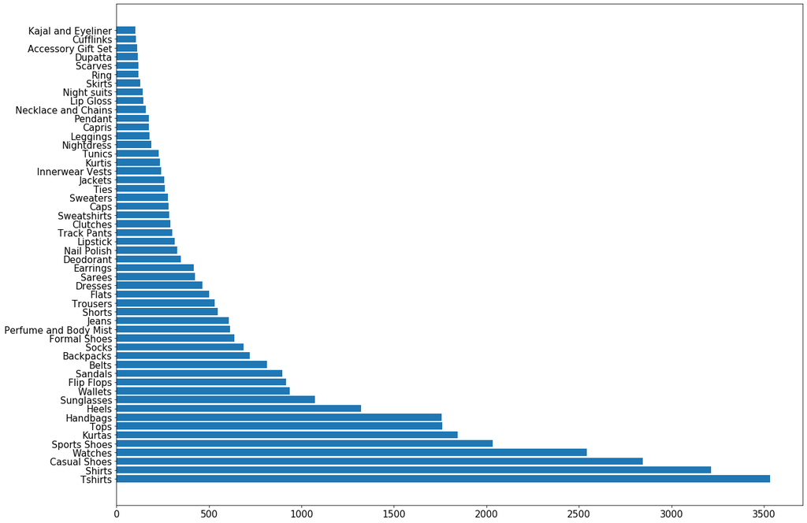

```python
def dataDistributionPlot(loader, classes):
    total_category_count = {classes[i] : 0 for i in range(len(classes))}
    for _, labels in loader:
        for label in labels:
            total_category_count[ classes[label] ] += 1
    lists = sorted(total_category_count.items(), key=lambda kv: kv[1], reverse=True)
    x, y = zip(*lists)
    print('max: ' + x[0],'/ min: ' + x[len(x)-1])
    plt.figure(figsize=(20,15))
    plt.rcParams.update({'font.size': 15})
    plt.barh(x, y, align='center')
    plt.show()
    plt.figure()

data_loader = DataLoader(dataset, batch_size=64, num_workers=16)
dataDistributionPlot(data_loader, classes)
```

## Picturing Random Images

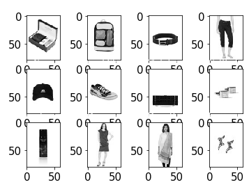

```python
def imageShow(data_iter, classes):
    fig, axs = plt.subplots(3, 4)
    cat = []
    c=0
    for i in range(len(data_iter)):
        if c == 12:
            break
        image, label = data_iter.next()
        if classes[label[0]] not in cat:
            x, y = int(c/4), int(c%4)
            c+=1
            cat.append(classes[label[0]])
            axs[x, y].imshow(image[0], cmap='gray')
            axs[x, y].set_title('%s' % (classes[label[0]]), fontsize=12, color='w')
    plt.show()

data_iter = iter(data_loader)
imageShow(data_iter, classes)
```

## Data to Loader

```python
def dataSplit(dataset, validation_split):
    N = len(dataset)
    test_selection = np.zeros(N)
    test_selection[np.random.choice(N,int(validation_split*N),replace=False)] = 1
    test_selection = test_selection.astype(bool)
    train_selection = ~test_selection
    indices = np.arange(N)
    test_indices = indices[test_selection]
    train_indices = indices[train_selection]
    return train_indices ,test_indices

def dataToLoader(dataset, train_indices ,test_indices, batch_size, num_workers):
    train_sampler = SubsetRandomSampler(train_indices)
    test_sampler = SubsetRandomSampler(test_indices)
    train_loader = DataLoader(dataset, batch_size=batch_size, sampler=train_sampler, num_workers=num_workers)
    test_loader = DataLoader(dataset, batch_size=batch_size, sampler=test_sampler, num_workers=num_workers)
    return train_loader ,test_loader

batch_size = 64
validation_split = 0.2
num_workers = 16

train_indices, test_indices = dataSplit(dataset, validation_split)
train_loader ,test_loader = dataToLoader(dataset, train_indices, test_indices, batch_size, num_workers)
```

## Network 1

In each network, I changed the weights and the number of layers in order to determine which of them works better.

```python
class Net1(nn.Module):
    def __init__(self, class_num, act=F.relu):
        super(Net1, self).__init__()
        self.layer1 = nn.Linear(80 * 60, 16 * 12 * 12)
        self.act1 = act
        self.layer2 = nn.Linear(16 * 12 * 12, 48 * 4 * 4)
        self.act2 = act
        self.layer3 = nn.Linear(48 * 4 * 4, 96 * 2 * 2)
        self.act3 = act
        self.layer4 = nn.Linear(96 * 2 * 2, 82)
        self.act4 = act
        self.layer5 = nn.Linear(82, class_num)

    def forward(self, x):
        x = x.view(x.size(0), -1)
        x = self.layer1(x)
        x = self.act1(x)
        x = self.layer2(x)
        x = self.act2(x)
        x = self.layer3(x)
        x = self.act3(x)
        x = self.layer4(x)
        x = self.act4(x)
        x = self.layer5(x)
        return x
```

```python
class Net2(nn.Module):
    def __init__(self, class_num, act=F.relu):
        super(Net2, self).__init__()
        self.layer1 = nn.Linear(80 * 60, 18 * 8 * 8)
        self.act1 = act
        self.layer2 = nn.Linear(18 * 8 * 8, 38 * 4 * 4)
        self.act2 = act
        self.layer3 = nn.Linear(38 * 4 * 4, 80 * 2 * 2)
        self.act3 = act
        self.layer4 = nn.Linear(80 * 2 * 2, class_num)

    def forward(self, x):
        x = x.view(x.size(0), -1)
        x = self.layer1(x)
        x = self.act1(x)
        x = self.layer2(x)
        x = self.act2(x)
        x = self.layer3(x)
        x = self.act3(x)
        x = self.layer4(x)
        return x
```

```python
class Net3(nn.Module):
    def __init__(self, class_num, act=F.relu):
        super(Net3, self).__init__()
        self.layer1 = nn.Linear(80 * 60, 20 * 10 * 10)
        self.act1 = act
        self.layer2 = nn.Linear(20 * 10 * 10, 40 * 8 * 8)
        self.act2 = act
        self.layer3 = nn.Linear(40 * 8 * 8, 70 * 4 * 4)
        self.act3 = act
        self.layer4 = nn.Linear(70 * 4 * 4, 100 * 2 * 2)
        self.act4 = act
        self.layer5 = nn.Linear(100 * 2 * 2, class_num)

    def forward(self, x):
        x = x.view(x.size(0), -1)
        x = self.layer1(x)
        x = self.act1(x)
        x = self.layer2(x)
        x = self.act2(x)
        x = self.layer3(x)
        x = self.act3(x)
        x = self.layer4(x)
        x = self.act4(x)
        x = self.layer5(x)
        return x
```

## Creating Device

```python
torch.cuda.empty_cache()
torch.cuda.synchronize()
device = torch.device("cuda:0" if torch.cuda.is_available() else "cpu")
print(device)
```

```
cuda:0
```

## Fitting Data

In this function I am going to train the networks and at the end I will calculate loss and then plot it.

```python
def get_lr(optimizer):
    for param_group in optimizer.param_groups:
        return param_group['lr']

def fit(model, train_loader, device, criterion, optimizer, num_epochs=10):
    total_time = 0.
    model = model.to(device)
    loss_list = []
    for epoch in range(num_epochs):
        train_loss = 0.
        d1 = datetime.now()
        for images, labels in train_loader:
            images = images.to(device)
            labels = labels.to(device)
            optimizer.zero_grad()
            outputs = model(images)
            loss = criterion(outputs, labels)
            loss.backward()
            optimizer.step()
            train_loss += loss.item()
            average_loss = train_loss / len(train_loader)
            d2 = datetime.now()
            delta = d2 - d1
            seconds = float(delta.total_seconds())
            total_time += seconds
        loss_list.append(average_loss)
    plt.ylabel('loss')
    plt.xlabel('epoch')
    plt.title('Loss Plot')
    plt.rcParams.update({'font.size': 7})
    lr = get_lr(optimizer)
    plt.plot(np.array(loss_list), label='loss lr={}'.format(lr))
    plt.legend()
#         print('total training time: %.3f minutes' % (total_time / 60))
```

```python
def test_model_accuracy(model, test_loader, plot=True):
    correct = 0.
    total = 0.
    y_pred = []
    y_label = []
    with torch.no_grad():
        for images, labels in test_loader:
            outputs = model(images.to(device))
            _, predicted = torch.max(outputs.data, 1)
            y_pred += predicted.tolist()
            y_label += labels.tolist()
            total += labels.size(0)
            correct += (predicted.to('cpu') == labels).sum().item()
    accuracy = 100 * correct / total
    y = recall_score(y_label, y_pred, average=None)
    if(plot):
        plt.figure()
        plt.ylabel('recall')
        plt.xlabel('categories')
        plt.title('Recall Plot')
        plt.rcParams.update({'font.size': 7})
        plt.bar([i for i in range(len(y))], y, align='center')
        plt.figure()
#     print('Accuracy: {}%'.format(accuracy))
    return accuracy
```

The weight array will be shown below. Its initial weights are set randomly and as it can be seen, its shape changes based on layers shape.

The loss value is NaN because our network didn't learn, so the plot will be empty.

[output not shown]

[output cut: 209 more lines]

[output not shown]

[figure not shown]

```python
model = Net1(len(classes))
learning_rate = 0.01
criterion = nn.CrossEntropyLoss()
optimizer = torch.optim.SGD(model.parameters(), lr=learning_rate)
for name, param in model.named_parameters():
    if param.requires_grad:
        print(name, param.data)
fit(model, train_loader, device, criterion, optimizer)
print('Accuracy Test: {}%'.format(test_model_accuracy(model, test_loader)))
print('Accuracy Train: {}%'.format(test_model_accuracy(model, train_loader)))
```

[output not shown]

[output cut: 149 more lines]

[output not shown]

[figure not shown]

```python
model = Net2(len(classes))
learning_rate = 0.01
criterion = nn.CrossEntropyLoss()
optimizer = torch.optim.SGD(model.parameters(), lr=learning_rate)
for name, param in model.named_parameters():
    if param.requires_grad:
        print(name, param.data)
fit(model, train_loader, device, criterion, optimizer)
print('Accuracy Test: {}%'.format(test_model_accuracy(model, test_loader)))
print('Accuracy Train: {}%'.format(test_model_accuracy(model, train_loader)))
```

[output not shown]

[output cut: 78 more lines]

[output not shown]

[figure not shown]

```python
model = Net3(len(classes))
learning_rate = 0.01
criterion = nn.CrossEntropyLoss()
optimizer = torch.optim.SGD(model.parameters(), lr=learning_rate)
for name, param in model.named_parameters():
    if param.requires_grad:
        print(name, param.data)
fit(model, train_loader, device, criterion, optimizer)
print('Accuracy Test: {}%'.format(test_model_accuracy(model, test_loader)))
print('Accuracy Train: {}%'.format(test_model_accuracy(model, train_loader)))
```

## Part 4

We should divide the RGB pixel numbers to 255 to have a number between 0 and 1. If we don't, the pixels with the higher number will get more value than the lower ones while they should be same. So by normalizing the data, this problem will be solved.

```python
class ToTensor(object):
    """Convert PIL Images in sample to pytorch Tensors."""
    def __call__(self, image):
        image = np.array(image, dtype=np.float32) / 255
        return torch.from_numpy(image)
```

```python
transform = transforms.Compose([transforms.Grayscale(), ToTensor()])
dataset = ImageFolder("./categorized_products", transform=transform)
classes = dataset.classes
batch_size = 64
validation_split = 0.2
num_workers = 16

train_indices, test_indices = dataSplit(dataset, validation_split)
train_loader ,test_loader = dataToLoader(dataset, train_indices, test_indices, batch_size, num_workers)
```

The plots shows that the second network is better than the others. Because it has better accuracy and also larger second derivative that cause faster rate of learning.

[output not shown]

[output cut: 232 more lines]

[output not shown]

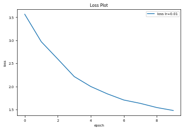

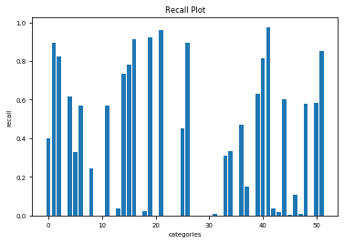

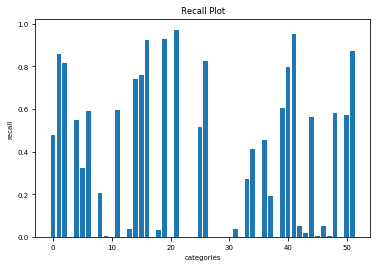

```python
model = Net1(len(classes))
learning_rate = 0.01
criterion = nn.CrossEntropyLoss()
optimizer = torch.optim.SGD(model.parameters(), lr=learning_rate)
for name, param in model.named_parameters():
    if param.requires_grad:
        print(name, param.data)
fit(model, train_loader, device, criterion, optimizer)
print('Accuracy Test: {}%'.format(test_model_accuracy(model, test_loader)))
print('Accuracy Train: {}%'.format(test_model_accuracy(model, train_loader)))
```

[output not shown]

[output cut: 169 more lines]

[output not shown]

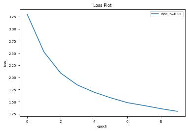

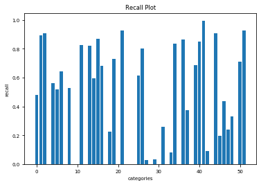

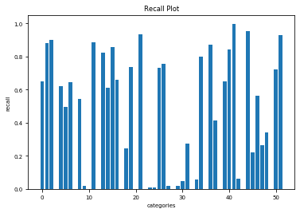

```python
model = Net2(len(classes))
learning_rate = 0.01
criterion = nn.CrossEntropyLoss()
optimizer = torch.optim.SGD(model.parameters(), lr=learning_rate)
for name, param in model.named_parameters():
    if param.requires_grad:
        print(name, param.data)
fit(model, train_loader, device, criterion, optimizer)
print('Accuracy Test: {}%'.format(test_model_accuracy(model, test_loader)))
print('Accuracy Train: {}%'.format(test_model_accuracy(model, train_loader)))
```

[output not shown]

[output cut: 46 more lines]

[output not shown]

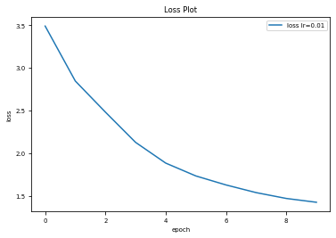

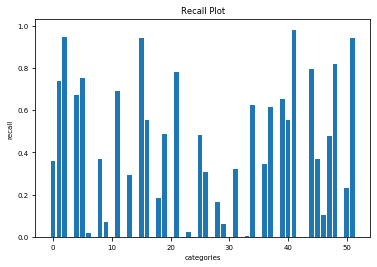

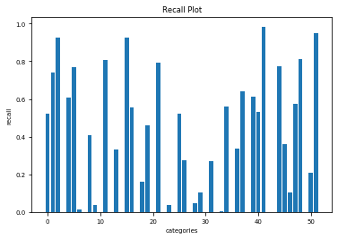

```python
model = Net3(len(classes))
learning_rate = 0.01
criterion = nn.CrossEntropyLoss()
optimizer = torch.optim.SGD(model.parameters(), lr=learning_rate)
for name, param in model.named_parameters():
    if param.requires_grad:
        print(name, param.data)
fit(model, train_loader, device, criterion, optimizer)
print('Accuracy Test: {}%'.format(test_model_accuracy(model, test_loader)))
print('Accuracy Train: {}%'.format(test_model_accuracy(model, train_loader)))
```

## Part 5

If all the weights are initialized with 0, the derivative with respect to loss function is the same for every w, thus all weights have the same value in subsequent iterations. This makes hidden units symmetric and continues for all the n iterations i.e. setting weights to 0 does not make it better than a linear model.

Assigning random values to weights is better than just 0 assignment. But there is one thing to keep in my mind is that weights should not be initialized with high values or very low values and what is a reasonable initialization of weight values.

[output not shown]

[output cut: 169 more lines]

[output not shown]

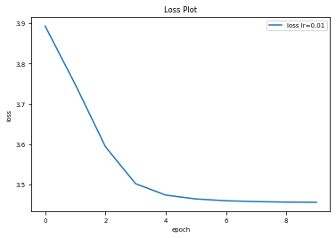

```python
model = Net2(len(classes))
model.layer1.weight.data.fill_(0.0)
model.layer1.bias.data.fill_(0.0)
learning_rate = 0.01
criterion = nn.CrossEntropyLoss()
optimizer = torch.optim.SGD(model.parameters(), lr=learning_rate)
for name, param in model.named_parameters():
    if param.requires_grad:
        print(name, param.data)
fit(model, train_loader, device, criterion, optimizer)
print('Accuracy Test: {}%'.format(test_model_accuracy(model, test_loader)))
print('Accuracy Train: {}%'.format(test_model_accuracy(model, train_loader)))
```

## Part 6

At extremes, a learning rate that is too large will result in weight updates that will be too large and the performance of the model (such as its loss on the training dataset) will oscillate over training epochs. Oscillating performance is said to be caused by weights that diverge (are divergent). A learning rate that is too small may never converge or may get stuck on a suboptimal solution.

When the learning rate is too large, gradient descent can inadvertently increase rather than decrease the training error. And when the learning rate is too small, training is not only slower, but may become permanently stuck with a high training error.

```
ACC : 51.26862666129682%
ACC : 61.26996912337226%
ACC : 69.29789233454154%
ACC : 71.91569338166197%
ACC : 70.82829910055041%
ACC : 75.51349174385824%
ACC : 69.67378171566654%
ACC : 69.8348771647201%
ACC : 76.09075043630017%
best acc : 76.09075043630017%
best lr : 0.09%
```

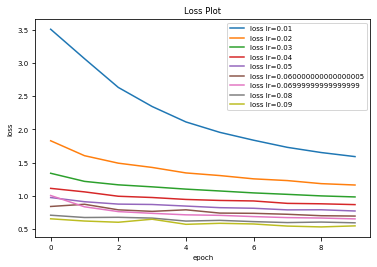

```python
model = Net2(len(classes))
best_acc = 0
best_learning_rate = 0
criterion = nn.CrossEntropyLoss()
for learning_rate in np.arange(0.01, 0.1, 0.01):
    optimizer = torch.optim.SGD(model.parameters(), lr=learning_rate)
    fit(model, train_loader, device, criterion, optimizer)
    acc = test_model_accuracy(model, test_loader, False)
    print("ACC : {}%".format(acc))
    if acc > best_acc:
        best_acc = acc
        best_learning_rate = learning_rate
print("best acc : {}%".format(best_acc))
print("best lr : {}%".format(best_learning_rate))
```

```
Accuracy Test: 17.492280843066183%
Accuracy Train: 17.251677852348994%
```

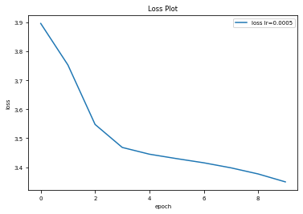

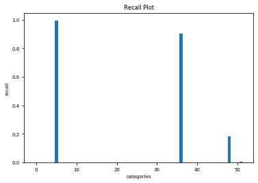

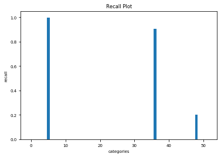

```python
model = Net2(len(classes))
learning_rate = 0.0005
criterion = nn.CrossEntropyLoss()
optimizer = torch.optim.SGD(model.parameters(), lr=learning_rate)
fit(model, train_loader, device, criterion, optimizer)
print('Accuracy Test: {}%'.format(test_model_accuracy(model, test_loader)))
print('Accuracy Train: {}%'.format(test_model_accuracy(model, train_loader)))
```

As we said earlier, the 0.5 learning rate is high for this situation. So it trains in a short time but after that it didn't train anymore.

```
Accuracy Test: 10.095314807356692%
Accuracy Train: 9.335570469798657%
```

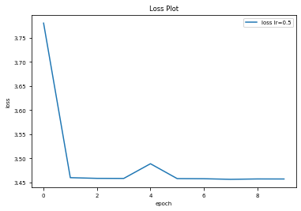

```python
model = Net2(len(classes))
learning_rate = 0.5
criterion = nn.CrossEntropyLoss()
optimizer = torch.optim.SGD(model.parameters(), lr=learning_rate)
fit(model, train_loader, device, criterion, optimizer)
print('Accuracy Test: {}%'.format(test_model_accuracy(model, test_loader)))
print('Accuracy Train: {}%'.format(test_model_accuracy(model, train_loader)))
```

## Part 7

The batch size defines the number of samples that will be propagated through the network.

Too large of a batch size will lead to poor generalization. The size of the update, depends heavily on which particular samples are drawn from the dataset. On the other hand using small batch size means the model makes updates that are all about the same size. The size of the update only weakly depends on which particular samples are drawn from the dataset.

“bigger batch size, bigger learning rate” because bigger batch size means more confidence in the direction of your “descent” of the error surface while the smaller a batch size is the closer you are to “stochastic” descent (batch size 1).

```
Accuracy Test: 67.78091018928716%
Accuracy Train: 69.19463087248322%
```

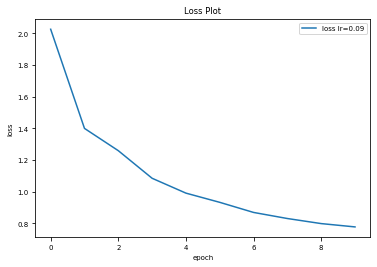

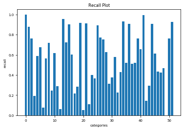

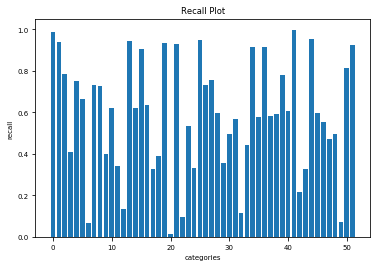

```python
batch_size = 32
train_indices, test_indices = dataSplit(dataset, validation_split)
train_loader ,test_loader = dataToLoader(dataset, train_indices, test_indices, batch_size, num_workers)
optimizer = torch.optim.SGD(model.parameters(), lr=best_learning_rate)
fit(model, train_loader, device, criterion, optimizer)
print('Accuracy Test: {}%'.format(test_model_accuracy(model, test_loader)))
print('Accuracy Train: {}%'.format(test_model_accuracy(model, train_loader)))
```

```
Accuracy Test: 79.72882266075983%
Accuracy Train: 84.76174496644295%
```

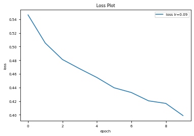

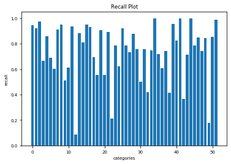

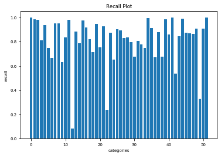

```python
batch_size = 128
train_indices, test_indices = dataSplit(dataset, validation_split)
train_loader ,test_loader = dataToLoader(dataset, train_indices, test_indices, batch_size, num_workers)
optimizer = torch.optim.SGD(model.parameters(), lr=best_learning_rate)
fit(model, train_loader, device, criterion, optimizer)
print('Accuracy Test: {}%'.format(test_model_accuracy(model, test_loader)))
print('Accuracy Train: {}%'.format(test_model_accuracy(model, train_loader)))
```

```
ACC : 87.28688414552289%
ACC : 86.84387166062558%
ACC : 85.55510806819707%
ACC : 85.08524634179085%
ACC : 83.16552557390254%
ACC : 82.33319908712579%
ACC : 81.74251577392938%
ACC : 81.63511880789368%
ACC : 81.33977715129548%
best acc : 87.28688414552289%
best lr : 0.01%
```

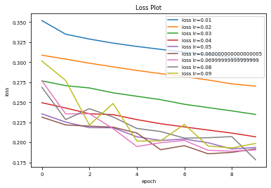

```python
batch_size = 128
train_indices, test_indices = dataSplit(dataset, validation_split)
train_loader ,test_loader = dataToLoader(dataset, train_indices, test_indices, batch_size, num_workers)
best_acc = 0
best_learning_rate_b = 0
criterion = nn.CrossEntropyLoss()
for learning_rate in np.arange(0.01, 0.1, 0.01):
    optimizer = torch.optim.SGD(model.parameters(), lr=learning_rate)
    fit(model, train_loader, device, criterion, optimizer)
    acc = test_model_accuracy(model, test_loader, False)
    print("ACC : {}%".format(acc))
    if acc > best_acc:
        best_acc = acc
        best_learning_rate_b = learning_rate
print("best acc : {}%".format(best_acc))
print("best lr : {}%".format(best_learning_rate_b))
```

## Part 8

To avoid stucking in the local minima, we use a momentum term in the objective function, which is a value between 0 and 1 that increases the size of the steps taken towards the minimum by trying to jump from a local minima. If the momentum term is large, then the learning rate should be kept smaller. A large value of momentum also means that the convergence will happen fast. But if both the momentum and learning rate are kept at large values, then you might skip the minimum with a huge step. A small value of momentum cannot reliably avoid local minima, and can also slow down the training of the system. Momentum also helps in smoothing out the variations, if the gradient keeps changing direction. A right value of momentum can be either learned by hit and trial or through cross-validation.

With Stochastic Gradient Descent we don’t compute the exact derivate of our loss function. Instead, we’re estimating it on a small batch. Which means we’re not always going in the optimal direction, because our derivatives are ‘noisy’. So, exponentially weighed averages can provide us a better estimate which is closer to the actual derivate than our noisy calculations.

```python
batch_size = 64
train_indices, test_indices = dataSplit(dataset, validation_split)
train_loader ,test_loader = dataToLoader(dataset, train_indices, test_indices, batch_size, num_workers)

optimizer = torch.optim.SGD(model.parameters(), lr=best_learning_rate, momentum=0.5)

fit(model, train_loader, device, criterion, optimizer)
print('Accuracy Test: {}%'.format(test_model_accuracy(model, test_loader)))
print('Accuracy Train: {}%'.format(test_model_accuracy(model, train_loader)))
```

```
Accuracy Test: 0.22821855282588266%
Accuracy Train: 0.31543624161073824%
```

```python
optimizer = torch.optim.SGD(model.parameters(), lr=best_learning_rate, momentum=0.9)

fit(model, train_loader, device, criterion, optimizer)
print('Accuracy Test: {}%'.format(test_model_accuracy(model, test_loader)))
print('Accuracy Train: {}%'.format(test_model_accuracy(model, train_loader)))
```

```
Accuracy Test: 0.22821855282588266%
Accuracy Train: 0.31543624161073824%
```

```python
optimizer = torch.optim.SGD(model.parameters(), lr=best_learning_rate, momentum=0.98)

fit(model, train_loader, device, criterion, optimizer)
print('Accuracy Test: {}%'.format(test_model_accuracy(model, test_loader)))
print('Accuracy Train: {}%'.format(test_model_accuracy(model, train_loader)))
```

```
Accuracy Test: 0.22821855282588266%
Accuracy Train: 0.31543624161073824%
```

## Part 9

The number of epochs is a hyperparameter of gradient descent that controls the number of complete passes through the training dataset.

Unfortunately, the sort of multidimensional data neural nets require is expensive to label and takes up large amounts of storage space. Thus, even though you need to feed your network lots of data, the amount of samples available is generally much lower than the number of samples you need to reach a useful optimum. There may be enough information in these training samples, but the gradient descent algorithm takes time to extract it. You can compensate for the limited number of samples by making multiple passes over the data. This will give the algorithm time to converge, without requiring an impractical amount of data.

In the process of minimizing error, it would have learnt the pattern but the error would not reach an absolute zero. If the training is continued for more epochs, model tries to reach zero error where it is starting to learn the noise of training data and overfitting happens.

```python
optimizer = torch.optim.SGD(model.parameters(), lr=best_learning_rate, momentum=0.5)

fit(model, train_loader, device, criterion, optimizer, 20)
print('Accuracy Test: {}%'.format(test_model_accuracy(model, test_loader)))
print('Accuracy Train: {}%'.format(test_model_accuracy(model, train_loader)))
```

```
Accuracy Test: 0.22821855282588266%
Accuracy Train: 0.31543624161073824%
```

## Part 10

The formula of these function are:

ReLU: max(0, x)

Leaky ReLU: max(0.1*x, x)

Tanh: tanh(x)

As we can see tanh has better result.

```
Accuracy Test: 42.70371861994899%
Accuracy Train: 42.87248322147651%
```

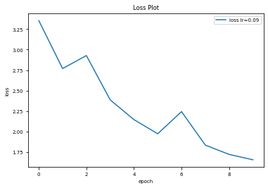

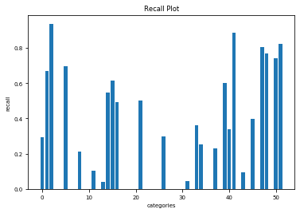

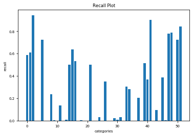

```python
model = Net2(len(classes), F.leaky_relu)
optimizer = torch.optim.SGD(model.parameters(), lr=best_learning_rate, momentum=0.5)
fit(model, train_loader, device, criterion, optimizer)
print('Accuracy Test: {}%'.format(test_model_accuracy(model, test_loader)))
print('Accuracy Train: {}%'.format(test_model_accuracy(model, train_loader)))
```

```
Accuracy Test: 64.27708417237213%
Accuracy Train: 66.03691275167785%
```

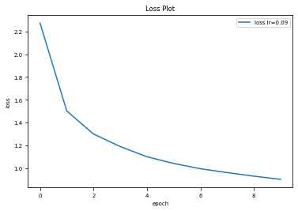

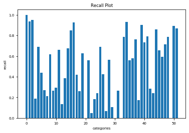

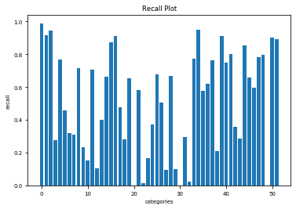

```python
model = Net2(len(classes), F.tanh)
optimizer = torch.optim.SGD(model.parameters(), lr=best_learning_rate, momentum=0.5)
fit(model, train_loader, device, criterion, optimizer)
print('Accuracy Test: {}%'.format(test_model_accuracy(model, test_loader)))
print('Accuracy Train: {}%'.format(test_model_accuracy(model, train_loader)))
```

```
Accuracy Test: 54.40998791784132%
Accuracy Train: 55.02348993288591%
```

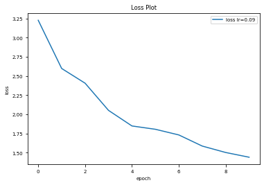

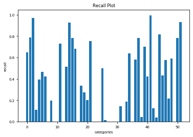

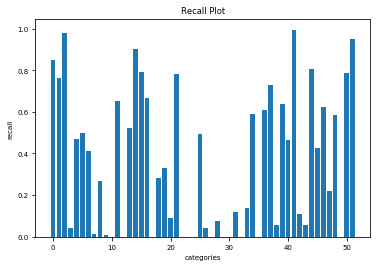

```python
model = Net2(len(classes))
optimizer = torch.optim.SGD(model.parameters(), lr=best_learning_rate, momentum=0.5)
fit(model, train_loader, device, criterion, optimizer)
print('Accuracy Test: {}%'.format(test_model_accuracy(model, test_loader)))
print('Accuracy Train: {}%'.format(test_model_accuracy(model, train_loader)))
```

## Part 11

Regularization is any modification we make to a learning algorithm that is intended to reduce its generalization error but not its training error.

Weight Regularization (weight decay) means penalize the model during training based on the magnitude of the weights. This will encourage the model to map the inputs to the outputs of the training dataset in such a way that the weights of the model are kept small. This approach is called weight regularization or weight decay and has proven very effective for decades for both simpler linear models and neural networks.

In here because by increasing the weight_decay, the weights are decreased so if the weight_decay be very high, it will avoid training.

```
Accuracy Test: 8.712578869646933%
Accuracy Train: 8.604026845637584%
```

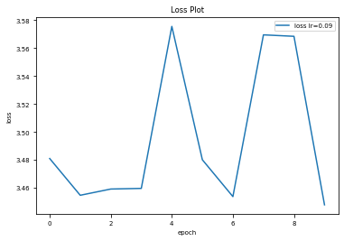

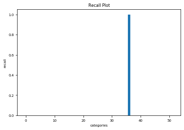

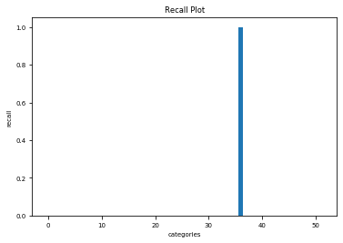

```python
model = Net2(len(classes))
optimizer = torch.optim.SGD(model.parameters(), lr=best_learning_rate, momentum=0.5, weight_decay=0.1)
fit(model, train_loader, device, criterion, optimizer)
print('Accuracy Test: {}%'.format(test_model_accuracy(model, test_loader)))
print('Accuracy Train: {}%'.format(test_model_accuracy(model, train_loader)))
```

```
Accuracy Test: 9.799973150758492%
Accuracy Train: 9.409395973154362%
```

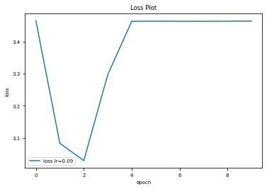

```python
model = Net1(len(classes))
optimizer = torch.optim.SGD(model.parameters(), lr=best_learning_rate, momentum=0.5, weight_decay=0.01)
fit(model, train_loader, device, criterion, optimizer)
print('Accuracy Test: {}%'.format(test_model_accuracy(model, test_loader)))
print('Accuracy Train: {}%'.format(test_model_accuracy(model, train_loader)))
```